# Time Series HW14

B082040005 高念慈

2023-05-26

## 1. Again, consider the returns in m-gmsp5008.txt.

```r
gmsp = read.table("https://faculty.chicagobooth.edu/-/media/faculty/ruey-s-tsay/teaching/fts3/m-gmsp5008.txt", header = T)
head(gmsp)
```

```
##       date        gm        sp
## 1 19500131  0.022688  0.017303
## 2 19500228  0.049488  0.009971
## 3 19500331  0.014925  0.004065
## 4 19500429  0.120915  0.045113
## 5 19500531  0.071429  0.039292
## 6 19500630 -0.031812 -0.058040
```

### (a)

Build a Gaussian GARCH model for the monthly log returns of the S&P 500 index.  
Check the model carefully.

```r
logrtn_gmsp = log(gmsp$sp + 1)
```

```r
Box.test(logrtn_gmsp,lag=12, type='Ljung')
```

```
##
##  Box-Ljung test
##
## data:  logrtn_gmsp
## X-squared = 12.837, df = 12, p-value = 0.381
```

- p-value > 0.05,the log return has no serial correlation

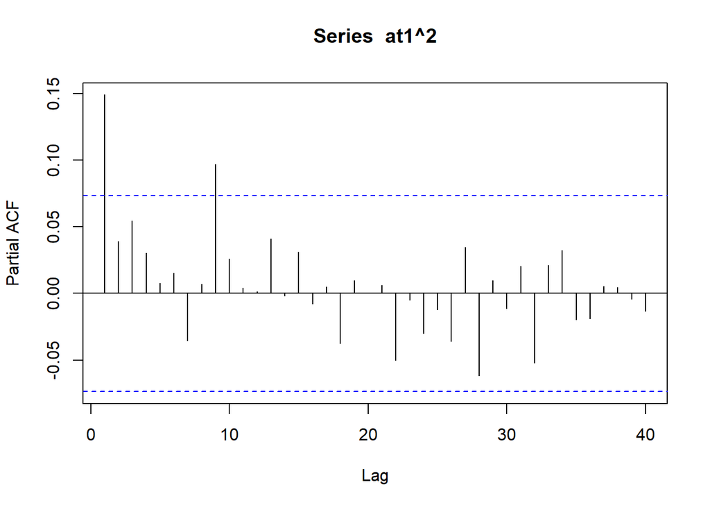

```r
at1 = logrtn_gmsp - mean(logrtn_gmsp)
pacf(at1^2, 40)  # AR 1 or 9
```

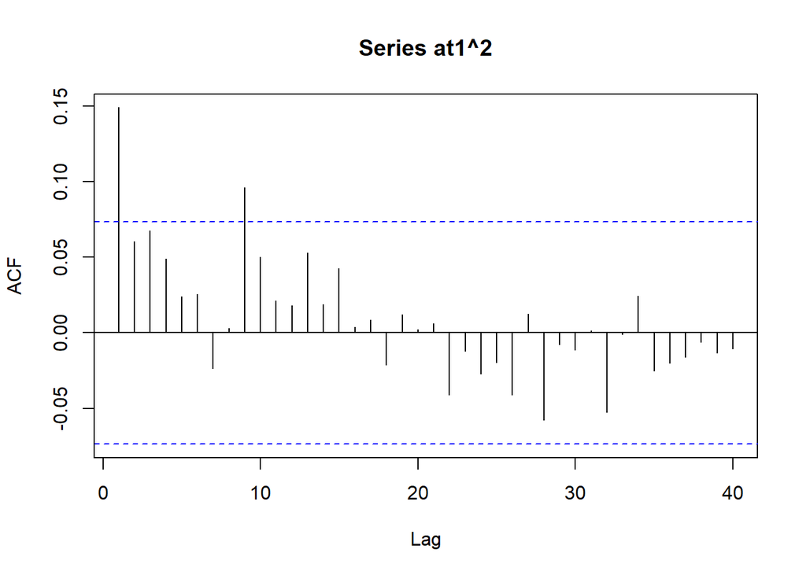

```r
acf(at1^2, 40)   # MA 1 or 9
```

```r
eacf(at1^2)      # ARMA(1,1) or MA1
```

```
## AR/MA
##   0 1 2 3 4 5 6 7 8 9 10 11 12 13
## 0 x o o o o o o o x o o  o  o  o
## 1 x o o o o o o o x o o  o  o  o
## 2 x x o o o o o o x o o  o  o  o
## 3 x x x o o o o o o o o  o  o  o
## 4 x x o x o o o o o o o  o  o  o
## 5 x x x o x o o o o o o  o  o  o
## 6 x x o o x o o o o o o  o  o  o
## 7 x x o o x o o o o o o  o  o  o
```

- $a^2_t$ ~ ARMA(1,1)

```r
# library(fGarch)
garch1.fit = garchFit(~ garch(1,1), data=logrtn_gmsp, trace=FALSE)
summary(garch1.fit)
```

```
##
## Title:
##  GARCH Modelling
##
## Call:
##  garchFit(formula = ~garch(1, 1), data = logrtn_gmsp, trace = FALSE)
##
## Mean and Variance Equation:
##  data ~ garch(1, 1)
## <environment: 0x0000000023bc8a78>
##  [data = logrtn_gmsp]
##
## Conditional Distribution:
##  norm
##
## Coefficient(s):
##         mu       omega      alpha1       beta1
## 6.2132e-03  8.0993e-05  1.1425e-01  8.4887e-01
##
## Std. Errors:
##  based on Hessian
##
## Error Analysis:
##         Estimate  Std. Error  t value Pr(>|t|)
## mu     6.213e-03   1.412e-03    4.400 1.08e-05 ***
## omega  8.099e-05   3.379e-05    2.397   0.0165 *
## alpha1 1.142e-01   2.648e-02    4.315 1.60e-05 ***
## beta1  8.489e-01   2.803e-02   30.286  < 2e-16 ***
## ---
## Signif. codes:  0 '***' 0.001 '**' 0.01 '*' 0.05 '.' 0.1 ' ' 1
##
## Log Likelihood:
##  1268.41    normalized:  1.79154
##
## Description:
##  Fri May 26 21:52:38 2023 by user: user
##
##
## Standardised Residuals Tests:
##                                 Statistic p-Value
##  Jarque-Bera Test   R    Chi^2  177.6952  0
##  Shapiro-Wilk Test  R    W      0.9735008 5.058713e-10
##  Ljung-Box Test     R    Q(10)  10.22153  0.4212773
##  Ljung-Box Test     R    Q(15)  15.16213  0.4398033
##  Ljung-Box Test     R    Q(20)  19.52303  0.488099
##  Ljung-Box Test     R^2  Q(10)  5.982056  0.8167685
##  Ljung-Box Test     R^2  Q(15)  6.912373  0.9600358
##  Ljung-Box Test     R^2  Q(20)  7.662483  0.9938757
##  LM Arch Test       R    TR^2   6.191671  0.9061132
##
## Information Criterion Statistics:
##       AIC       BIC       SIC      HQIC
## -3.571780 -3.546003 -3.571843 -3.561821
```

- $a_t $ & $a_t^2$ has no serial correlation and all the coefficients are significant.Thus,the model is adequate.

### WAY2

```r
# library(rugarch)

mean.model = list(armaOrder=c(0,0), include.mean=TRUE)
variance.model = list(model="sGARCH", garchOrder=c(1,1))

spec = ugarchspec(mean.model=mean.model,
                  variance.model=variance.model,
                  distribution.model="norm")
```

- model fitting

```r
fitmodel1 = ugarchfit(data = logrtn_gmsp, spec = spec)
fitmodel1
```

```
##
## *---------------------------------*
## *          GARCH Model Fit        *
## *---------------------------------*
##
## Conditional Variance Dynamics
## -----------------------------------
## GARCH Model  : sGARCH(1,1)
## Mean Model   : ARFIMA(0,0,0)
## Distribution : norm
##
## Optimal Parameters
## ------------------------------------
##         Estimate  Std. Error  t value Pr(>|t|)
## mu      0.006214    0.001412   4.4015 0.000011
## omega   0.000081    0.000034   2.3911 0.016799
## alpha1  0.114440    0.026548   4.3108 0.000016
## beta1   0.848851    0.028085  30.2248 0.000000
##
## Robust Standard Errors:
##         Estimate  Std. Error  t value Pr(>|t|)
## mu      0.006214    0.001550   4.0088 0.000061
## omega   0.000081    0.000043   1.8935 0.058288
## alpha1  0.114440    0.034457   3.3213 0.000896
## beta1   0.848851    0.034557  24.5639 0.000000
##
## LogLikelihood : 1268.422
##
## Information Criteria
## ------------------------------------
##
## Akaike       -3.5718
## Bayes        -3.5460
## Shibata      -3.5719
## Hannan-Quinn -3.5619
##
## Weighted Ljung-Box Test on Standardized Residuals
## ------------------------------------
##                         statistic p-value
## Lag[1]                     0.7719  0.3796
```

[output cut: 37 more lines]

```
## Negative Sign Bias   0.658 0.5107216
## Positive Sign Bias   1.459 0.1448981
## Joint Effect        18.502 0.0003466 ***
##
##
## Adjusted Pearson Goodness-of-Fit Test:
## ------------------------------------
##   group statistic p-value(g-1)
## 1    20     50.02    0.0001301
## 2    30     61.32    0.0004217
## 3    40     74.15    0.0005820
## 4    50     84.23    0.0013009
##
##
## Elapsed time : 0.08673406
```

### (b)

Is there a summer effect on the volatility of the index return?  
Use the GARCH model built in part (a) to answer this question.

```r
summer = c(0,0,0,0,0,1,1,1,0,0,0,0)
summer_eff = rep(summer, 59)
summer_eff = as.matrix(summer_eff)
```

- Plug in (插入) the exogenous (外生) variable

```r
spec2 = ugarchspec(mean.model = mean.model,
                   variance.model = list(model = "sGARCH", garchOrder = c(1,1),
                                         external.regressors = summer_eff),
                   distribution.model = "norm")
fitmodel2 = ugarchfit(data = logrtn_gmsp, spec = spec2)
fitmodel2
```

```
##
## *---------------------------------*
## *          GARCH Model Fit        *
## *---------------------------------*
##
## Conditional Variance Dynamics
## -----------------------------------
## GARCH Model  : sGARCH(1,1)
## Mean Model   : ARFIMA(0,0,0)
## Distribution : norm
##
## Optimal Parameters
## ------------------------------------
##         Estimate  Std. Error  t value Pr(>|t|)
## mu      0.006306    0.001435  4.39310 0.000011
## omega   0.000029    0.000039  0.75172 0.452220
## alpha1  0.099482    0.026234  3.79216 0.000149
## beta1   0.845978    0.031378 26.96087 0.000000
## vxreg1  0.000302    0.000118  2.56203 0.010406
##
## Robust Standard Errors:
##         Estimate  Std. Error  t value Pr(>|t|)
## mu      0.006306    0.001606   3.9273 0.000086
## omega   0.000029    0.000045   0.6401 0.522108
## alpha1  0.099482    0.036243   2.7449 0.006053
## beta1   0.845978    0.037280  22.6926 0.000000
## vxreg1  0.000302    0.000161   1.8701 0.061467
##
## LogLikelihood : 1272.151
##
## Information Criteria
## ------------------------------------
##
## Akaike       -3.5795
## Bayes        -3.5473
## Shibata      -3.5796
## Hannan-Quinn -3.5671
##
## Weighted Ljung-Box Test on Standardized Residuals
## ------------------------------------
```

[output cut: 40 more lines]

```
## Negative Sign Bias  0.4595 0.6460437
## Positive Sign Bias  1.4318 0.1526447
## Joint Effect       18.2021 0.0003996 ***
##
##
## Adjusted Pearson Goodness-of-Fit Test:
## ------------------------------------
##   group statistic p-value(g-1)
## 1    20     35.50     0.012141
## 2    30     50.31     0.008372
## 3    40     65.45     0.005034
## 4    50     74.20     0.011559
##
##
## Elapsed time : 0.1208639
```

- In the optimal parameter, vxreg1(summer) = 0.000302 (pvalue=0.0104 < 0.05),
- so there are summer effect in the index garch model.

### (c)

Are lagged returns of GM stock useful in modeling the index volatility?  
Again, use the GARCH model of part (a) as a baseline model for comparison.

```r
fitmodel3 = ugarchfit(data = gmsp$gm, spec = spec)
fitmodel3
```

```
##
## *---------------------------------*
## *          GARCH Model Fit        *
## *---------------------------------*
##
## Conditional Variance Dynamics
## -----------------------------------
## GARCH Model  : sGARCH(1,1)
## Mean Model   : ARFIMA(0,0,0)
## Distribution : norm
##
## Optimal Parameters
## ------------------------------------
##         Estimate  Std. Error  t value Pr(>|t|)
## mu      0.011263    0.002419   4.6556 0.000003
## omega   0.000116    0.000063   1.8455 0.064959
## alpha1  0.104019    0.024114   4.3136 0.000016
## beta1   0.884230    0.027120  32.6038 0.000000
##
## Robust Standard Errors:
##         Estimate  Std. Error  t value Pr(>|t|)
## mu      0.011263    0.002379   4.7346 0.000002
## omega   0.000116    0.000059   1.9492 0.051274
## alpha1  0.104019    0.020915   4.9733 0.000001
## beta1   0.884230    0.023578  37.5025 0.000000
##
## LogLikelihood : 868.9197
##
## Information Criteria
## ------------------------------------
##
## Akaike       -2.4433
## Bayes        -2.4175
## Shibata      -2.4433
## Hannan-Quinn -2.4333
##
## Weighted Ljung-Box Test on Standardized Residuals
## ------------------------------------
##                         statistic p-value
## Lag[1]                      1.414  0.2343
```

[output cut: 37 more lines]

```
## Negative Sign Bias  0.4677 0.64015
## Positive Sign Bias  0.3787 0.70502
## Joint Effect        9.6697 0.02159  **
##
##
## Adjusted Pearson Goodness-of-Fit Test:
## ------------------------------------
##   group statistic p-value(g-1)
## 1    20     24.43       0.1802
## 2    30     28.10       0.5125
## 3    40     43.75       0.2768
## 4    50     49.63       0.4481
##
##
## Elapsed time : 0.06930995
```